```python
import numpy as np
import pandas as pd
import matplotlib.pyplot as plt
import seaborn as sns
```

# DATA EXPLORATION

```python
#import the dataset
df = pd.read_csv('Default_Fin.csv', index_col=0)
df.head()
```

| Index | Employed | Bank Balance | Annual Salary | Defaulted? |
| --- | --- | --- | --- | --- |
| 1 | 1 | 8754.36 | 532339.56 | 0 |
| 2 | 0 | 9806.16 | 145273.56 | 0 |
| 3 | 1 | 12882.60 | 381205.68 | 0 |
| 4 | 1 | 6351.00 | 428453.88 | 0 |
| 5 | 1 | 9427.92 | 461562.00 | 0 |

```python
#rename the target column
df.rename(columns = {'Defaulted?': 'Defaulted'}, inplace = True)
df.info()
```

```
<class 'pandas.core.frame.DataFrame'>
Index: 10000 entries, 1 to 10000
Data columns (total 4 columns):
 #   Column         Non-Null Count  Dtype
---  ------         --------------  -----
 0   Employed       10000 non-null  int64
 1   Bank Balance   10000 non-null  float64
 2   Annual Salary  10000 non-null  float64
 3   Defaulted      10000 non-null  int64
dtypes: float64(2), int64(2)
memory usage: 390.6 KB
```

There are no null values to be filled and the dataset contains 10000 observations (rows of data).

```python
percent_defaulters = df['Defaulted'].value_counts().values[1] * 100/df['Defaulted'].value_counts().sum()
print('The dataset contains {}% defaulters'.format(percent_defaulters))
df['Defaulted'].value_counts()
```

```
The dataset contains 3.33% defaulters
```

```
Defaulted
0    9667
1     333
Name: count, dtype: int64
```

We have a very imbalanced set of observations here with just 333 out of 10000 customers being defaulters.

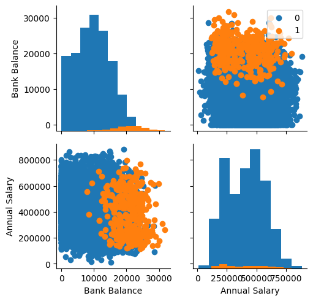

```python
g = sns.PairGrid(data = df, vars=['Bank Balance', 'Annual Salary'], hue='Defaulted')
g.map_diag(plt.hist)
g.map_offdiag(plt.scatter)
plt.legend();
```

```python
df.groupby('Defaulted')[['Bank Balance', 'Annual Salary']].describe()
```

| Defaulted | Bank Balance count | Bank Balance mean | Bank Balance std | Bank Balance min | Bank Balance 25% | Bank Balance 50% | Bank Balance 75% | Bank Balance max | Annual Salary count | Annual Salary mean | Annual Salary std | Annual Salary min | Annual Salary 25% | Annual Salary 50% | Annual Salary 75% | Annual Salary max |
| --- | --- | --- | --- | --- | --- | --- | --- | --- | --- | --- | --- | --- | --- | --- | --- | --- |
| 0 | 9667.0 | 9647.324961 | 5477.714672 | 0.0 | 5588.58 | 9634.32 | 13539.00 | 28692.12 | 9667.0 | 402793.999321 | 159819.015334 | 9263.64 | 256860.72 | 415073.88 | 525885.06 | 882650.76 |
| 1 | 333.0 | 20973.858378 | 4095.198311 | 7828.8 | 18139.32 | 21469.08 | 23866.44 | 31851.84 | 333.0 | 385069.762162 | 165650.649999 | 115965.48 | 228330.12 | 378184.08 | 516807.96 | 797597.52 |

We can clearly see that the minimum Bank balance and Annual Salary for those that default loans are #7828 and #115965 respectively.

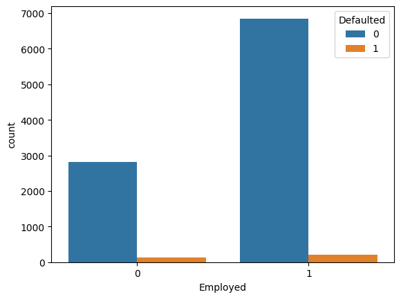

```python
sns.countplot(data = df, x='Employed', hue='Defaulted')
```

## PREPROCESSING FOR MODELLING

```python
#splitting
from sklearn.model_selection import train_test_split
from sklearn import preprocessing

x = df[['Employed', 'Bank Balance', 'Annual Salary']]
y = df['Defaulted']
train_x, test_x, train_y, test_y = train_test_split(x, y ,test_size = 0.25, random_state= 6)
```

```python
train_y.value_counts()
```

```
Defaulted
0    7252
1     248
Name: count, dtype: int64
```

```python
#normalizing Bank Balance and Annual Salary
train_x_norm = preprocessing.StandardScaler().fit(train_x).transform(train_x.astype(float))
test_x_norm = preprocessing.StandardScaler().fit(test_x).transform(test_x.astype(float))
```

### KNN

```python
#modelling, predicting and evaluation
from sklearn.neighbors import KNeighborsClassifier
from sklearn import metrics
knn_model = KNeighborsClassifier(n_neighbors = 3).fit(train_x_norm, train_y)
knn_predict = knn_model.predict(test_x_norm)
print("The Accuracy Score for this model is ", metrics.accuracy_score(test_y, knn_predict))
print("The f1_score for this model is ", metrics.f1_score(test_y, knn_predict))
```

```
The Accuracy Score for this model is  0.97
The f1_score for this model is  0.4827586206896552
```

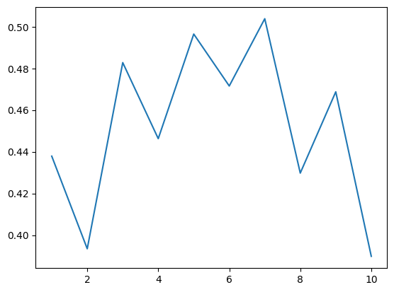

```python
k = np.arange(1, 11, 1)
lis = []
for p in k:
    knn = KNeighborsClassifier(n_neighbors = p).fit(train_x_norm, train_y)
    knn_pr = knn.predict(test_x_norm)
    lis.append(metrics.f1_score(test_y, knn_pr))

plt.plot(k, lis)
```

From this plot, the optimal value of neighbours is 7

```python
knn_model = KNeighborsClassifier(n_neighbors = 7).fit(train_x_norm, train_y)
knn_predict = knn_model.predict(test_x_norm)
print("The Accuracy Score for this model is ", metrics.accuracy_score(test_y, knn_predict))
print("The f1_score for this model is ", metrics.f1_score(test_y, knn_predict))
```

```
The Accuracy Score for this model is  0.974
The f1_score for this model is  0.5038167938931297
```

```python
# Confusion matrix method
def plot_conf(data):
    confusion_matrix = metrics.confusion_matrix(test_y, data)
    cm_display = metrics.ConfusionMatrixDisplay(confusion_matrix = confusion_matrix, display_labels=[0, 1])
    cm_display.plot()
    plt.show()
```

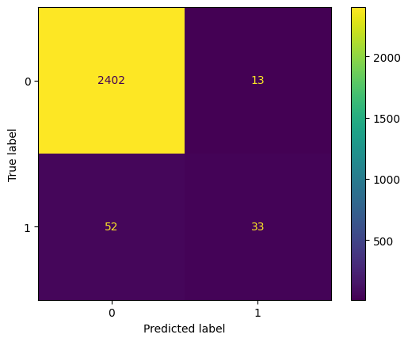

```python
plot_conf(knn_predict)
```

LOGISTIC REGRESSION MODEL

```python
from sklearn.linear_model import LogisticRegression
lr_model = LogisticRegression(C=0.1, solver='liblinear').fit(train_x_norm, train_y)
lr_proba = pd.Series(lr_model.predict_proba(test_x_norm)[:,1])
```

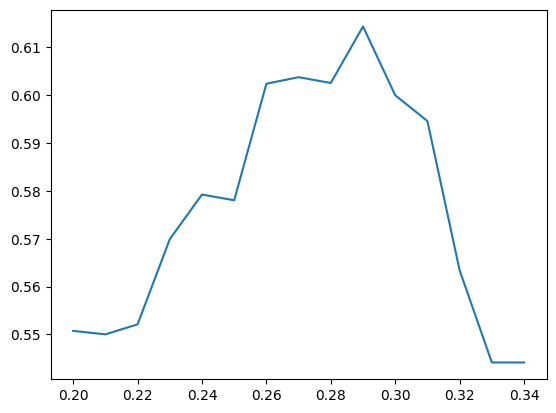

```python
#to tune the probability cutoff for the optimal model performance
def tune_proba(proba, threshold):
    if proba > threshold:
        return 1
    else: return 0

scores = []
for a in np.arange(0.2, 0.35, 0.01):
    scores.append(metrics.f1_score(test_y, lr_proba.apply(tune_proba ,args = (a,))))

plt.plot(np.arange(0.2,0.35, 0.01), scores)
```

```python
lr_predict = lr_proba.apply(tune_proba, args=(0.29, ))
```

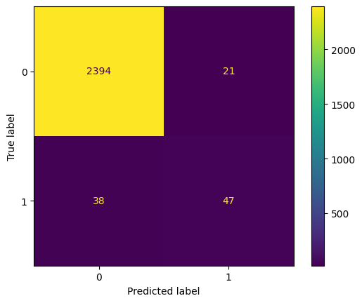

```python
plot_conf(lr_predict)
```

```python
print("The Accuracy Score for this model is ", metrics.accuracy_score(test_y, lr_predict))
print("The f1_score for this model is ", metrics.f1_score(test_y, lr_predict))
```

```
The Accuracy Score for this model is  0.9764
The f1_score for this model is  0.6143790849673203
```

SUPPORT VECTOR MACHINE

```python
from sklearn import svm
svm_kernels = ['rbf', 'linear', 'sigmoid', 'poly']
for kernels in svm_kernels:
    svm_model = svm.SVC(kernel=kernels).fit(train_x_norm, train_y)
    svm_predict = svm_model.predict(test_x_norm)
    print(kernels, metrics.f1_score(test_y, svm_predict))
```

```
rbf 0.3486238532110092
linear 0.0
sigmoid 0.29714285714285715
poly 0.2857142857142857
```

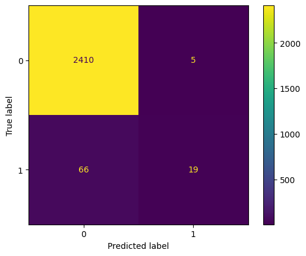

```python
svm_model = svm.SVC(kernel='rbf').fit(train_x_norm, train_y)
svm_predict = svm_model.predict(test_x_norm)
plot_conf(svm_predict)
```

```python
print("The Accuracy Score for this model is ", metrics.accuracy_score(test_y, svm_predict))
print("The f1_score for this model is ", metrics.f1_score(test_y, svm_predict))
```

```
The Accuracy Score for this model is  0.9716
The f1_score for this model is  0.3486238532110092
```

DECISION TREE

```python
from sklearn.tree import DecisionTreeClassifier

dt_model = DecisionTreeClassifier(criterion='entropy').fit(train_x_norm, train_y)
dt_predict = dt_model.predict(test_x_norm)
print("The f1_score is {}".format(metrics.f1_score(test_y, dt_predict)))
```

```
The f1_score is 0.4049079754601227
```

```python
lengths = [3, 4, 5, 6, 7, 8, 9, 10, 20, 50, 100]
for length in lengths:
    dtree = DecisionTreeClassifier(criterion = 'entropy', max_leaf_nodes = length).fit(train_x_norm, train_y)
    pre = dtree.predict(test_x_norm)
    print(length, metrics.f1_score(test_y, pre))
```

```
3 0.510948905109489
4 0.510948905109489
5 0.510948905109489
6 0.510948905109489
7 0.510948905109489
8 0.510948905109489
9 0.33027522935779813
10 0.33027522935779813
20 0.43333333333333335
50 0.4812030075187971
100 0.39062500000000006
```

This means the model performs best when the maximum number of leaf nodes is an integer between 3 and 8

```python
dtree = DecisionTreeClassifier(criterion = 'entropy', max_leaf_nodes = 3).fit(train_x_norm, train_y)
dtree_predict = dtree.predict(test_x_norm)
print("The Accuracy Score for this model is ", metrics.accuracy_score(test_y, dtree_predict))
print("The f1_score for this model is ", metrics.f1_score(test_y, dtree_predict))
```

```
The Accuracy Score for this model is  0.9732
The f1_score for this model is  0.510948905109489
```

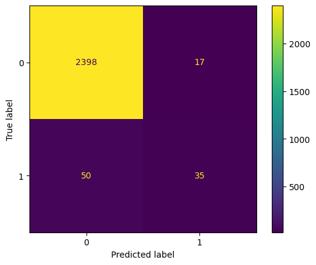

```python
plot_conf(dtree_predict)
```

### OVERSAMPLING AND UNDERSAMPLING TECHNIQUES

Since the logistic regression model has the best performance, let us see if we can improve the model performance by resampling the data.

```
0.9300000000000006 0.632258064516129
```

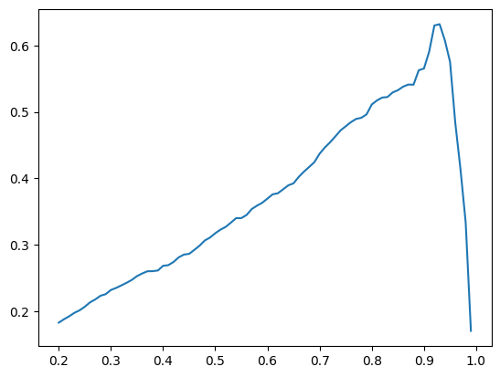

```python
from imblearn.over_sampling import RandomOverSampler
from imblearn.under_sampling import RandomUnderSampler

oversampler = RandomOverSampler(sampling_strategy='minority', random_state=2)
x_over, y_over = oversampler.fit_resample(train_x_norm, train_y)

lr_over_proba = pd.Series(lr_model.fit(x_over, y_over).predict_proba(test_x_norm)[:, 1])

scores = []
for a in np.arange(0.2, 1, 0.01):
    scores.append(metrics.f1_score(test_y, lr_over_proba.apply(tune_proba ,args = (a,))))

plt.plot(np.arange(0.2,1, 0.01), scores)
print(np.arange(0.2, 1, 0.01)[scores.index(max(scores))], max(scores))
```

```python
undersampler = RandomUnderSampler(sampling_strategy='majority')
x_under, y_under = undersampler.fit_resample(train_x_norm, train_y)

lr_under_proba = pd.Series(lr_model.fit(x_under, y_under).predict_proba(test_x_norm)[:, 1])

scores = []
for a in np.arange(0.2, 1, 0.01):
    scores.append(metrics.f1_score(test_y, lr_under_proba.apply(tune_proba ,args = (a,))))

print(np.arange(0.2, 1, 0.01)[scores.index(max(scores))], max(scores))
```

```
0.8800000000000006 0.6025641025641025
```

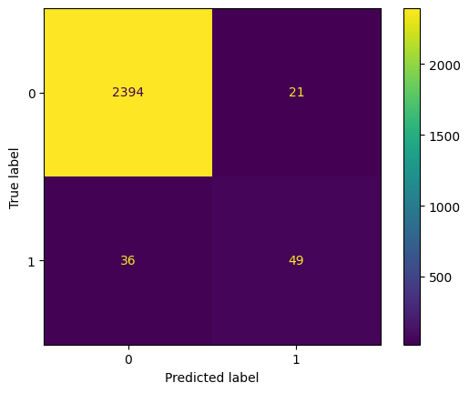

```python
#the oversampled data improves the logistic regression model performance, so let's go with that
plot_conf(lr_over_proba.apply(tune_proba ,args = (0.93,)))
```

```python
preeeed = lr_over_proba.apply(tune_proba ,args = (0.93,))
print(metrics.classification_report(test_y, preeeed))
```

```
              precision    recall  f1-score   support

           0       0.99      0.99      0.99      2415
           1       0.70      0.58      0.63        85

    accuracy                           0.98      2500
   macro avg       0.84      0.78      0.81      2500
weighted avg       0.98      0.98      0.98      2500
```

The final model has an impressive accuracy score of 98% and can accurately predict a defaulter 49 out of 85 times i.e an f1 score of 0.63 for the minority class. While this f1 score may not be very impressive, the model is working with just 3 features: Employed, Bank Balance and Annual Salary. If more features are provided such as whether or not they have properties, number of children and so on, an improved performance is expected.